# Devphotodraw_main_anlayses

### Correlates humans vs vgg classifications

```
##
##  Pearson's product-moment correlation
##
## data:  humans_merged$num_correct and humans_merged$target_label_prob
## t = 31.701, df = 2732, p-value < 2.2e-16
## alternative hypothesis: true correlation is not equal to 0
## 95 percent confidence interval:
##  0.4906250 0.5454582
## sample estimates:
##       cor
## 0.5185746
```

```
##
##  Pearson's product-moment correlation
##
## data:  humans_merged$num_correct and humans_merged$correct_or_not
## t = 22.784, df = 2732, p-value < 2.2e-16
## alternative hypothesis: true correlation is not equal to 0
## 95 percent confidence interval:
##  0.3676025 0.4306202
## sample estimates:
##       cor
## 0.3995834
```

## Main descriptive anlayses

### Compute accuracy by age, condition, site

### Plot accuracy by age, condition, site

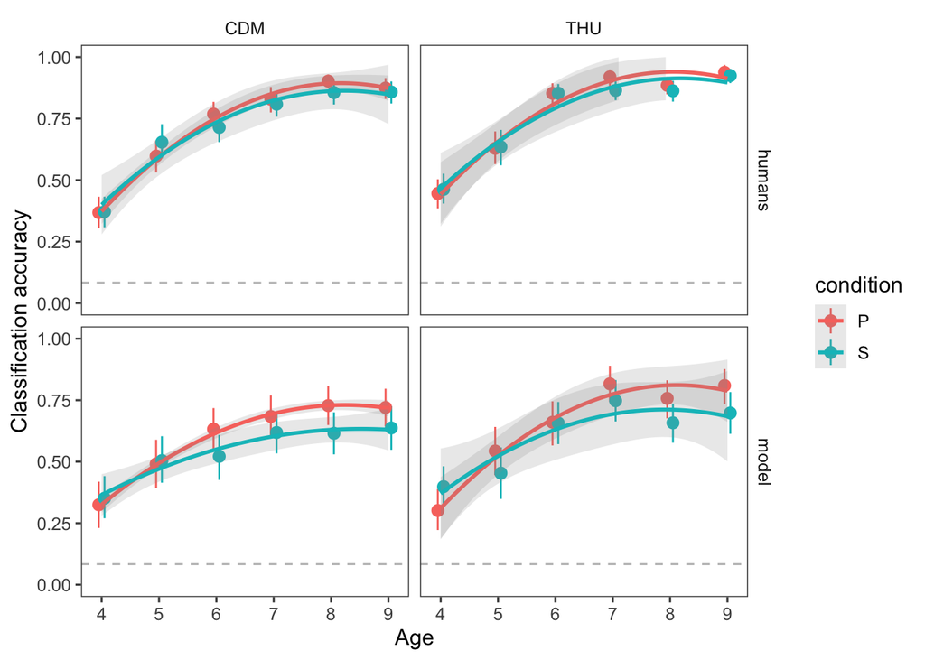

### Compute effort/tracing by age, condition, site

### Plot effort/tracing by age, condition, site

### Plot effort covariates

Looks like THU kids spent more time on drawings, interesting; otherwise no big differences.

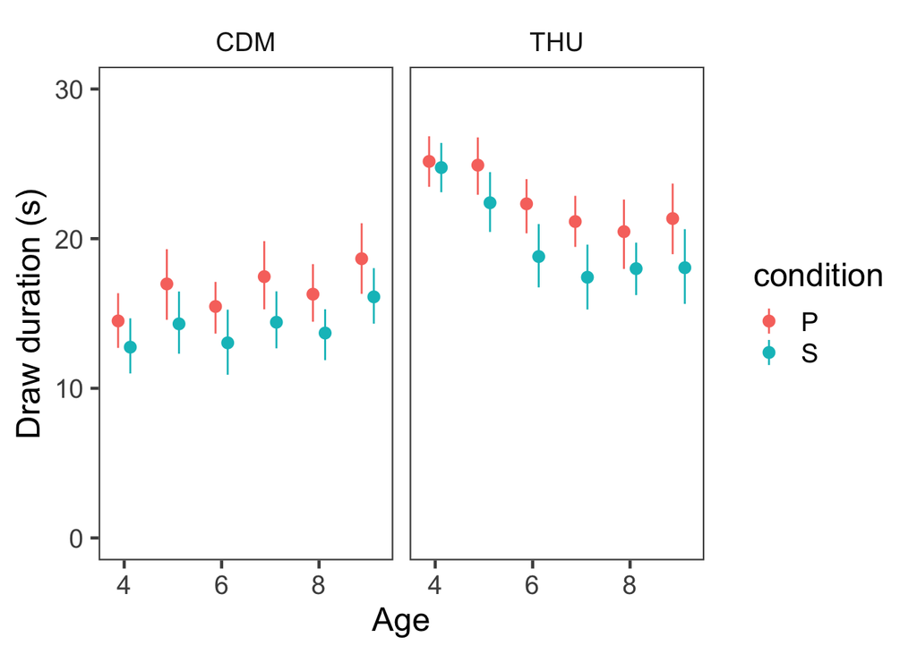

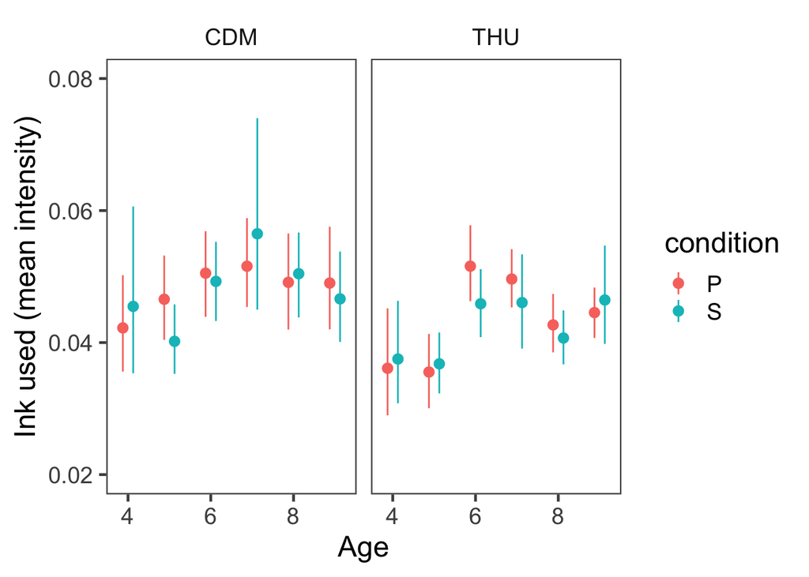

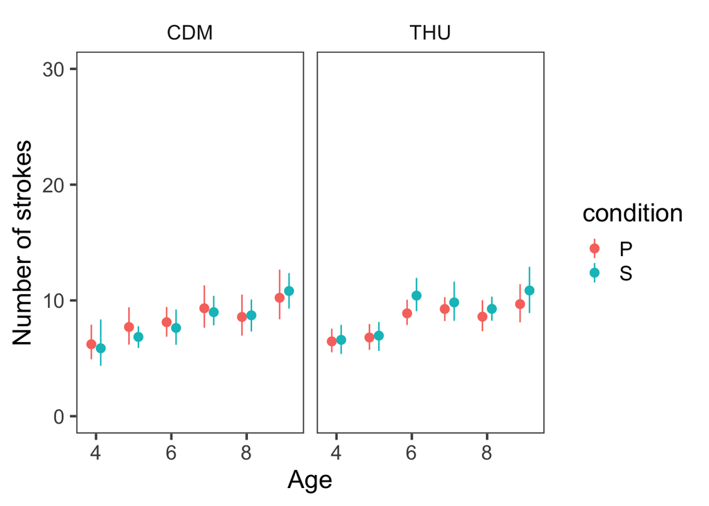

### Plot traing scores

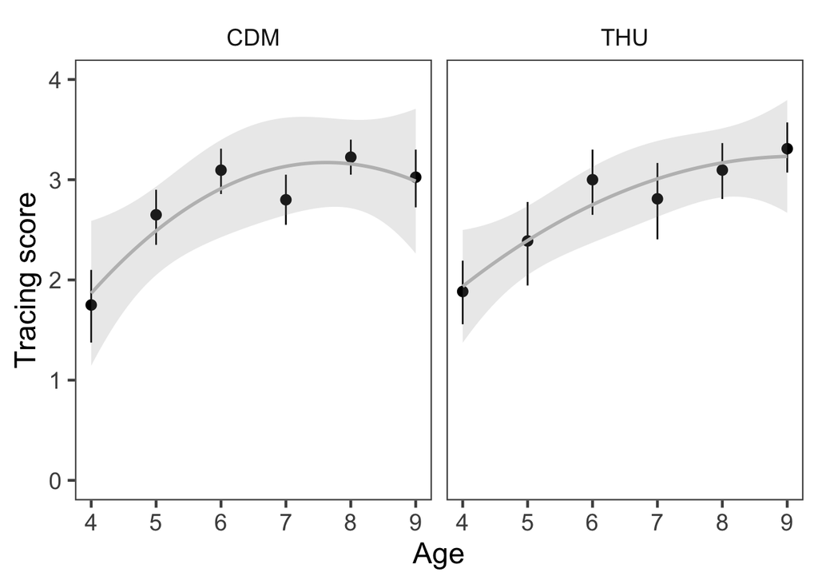

## Correlation of item effects across sites

Wow, cats are always badly classified.

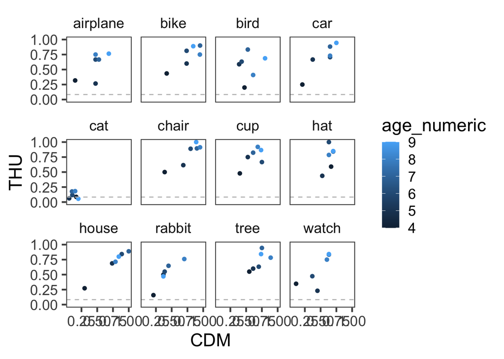

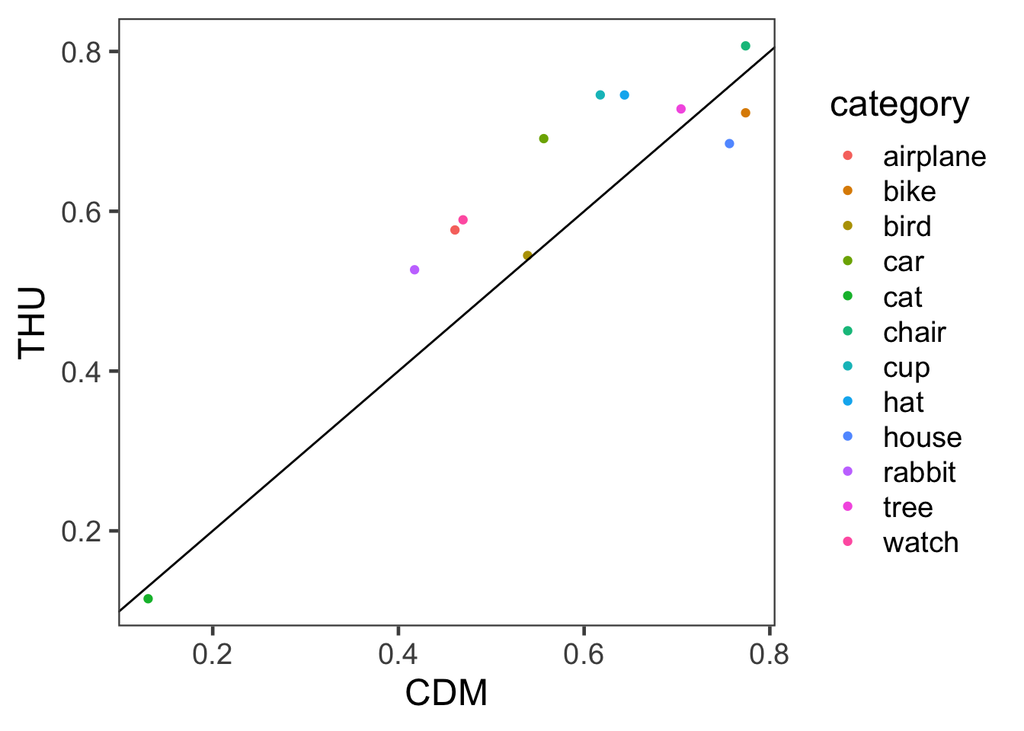

# Inferential stats

## Try maximumal model first

Singular boundary fits when including (condition | subject) random slopes Won’t converge with random slopes for condition x age xs ite on each category

```
## Generalized linear mixed model fit by maximum likelihood (Laplace
##   Approximation) [glmerMod]
##  Family: binomial  ( logit )
## Formula: correct_or_not ~ condition * scale(age_numeric) * site + (1 |
##     unique_ids) + (condition * scale(age_numeric) | category)
##    Data: d
## Control:
## glmerControl(optCtrl = list(maxfun = 20000), optimizer = c("bobyqa"))
##
##      AIC      BIC   logLik deviance df.resid
##   3127.2   3239.6  -1544.6   3089.2     2715
##
## Scaled residuals:
##     Min      1Q  Median      3Q     Max
## -3.8456 -0.7734  0.3602  0.6834  3.7179
##
## Random effects:
##  Groups     Name                          Variance Std.Dev. Corr
##  unique_ids (Intercept)                   0.23877  0.4886
##  category   (Intercept)                   0.85227  0.9232
##             conditionS                    0.35149  0.5929   -0.14
##             scale(age_numeric)            0.06120  0.2474    0.88 -0.44
##             conditionS:scale(age_numeric) 0.08874  0.2979   -0.29  0.88
##
##
##
##
##
##  -0.50
## Number of obs: 2734, groups:  unique_ids, 253; category, 12
##
## Fixed effects:
##                                       Estimate Std. Error z value Pr(>|z|)
## (Intercept)                            0.48773    0.28527   1.710   0.0873
## conditionS                            -0.29684    0.21365  -1.389   0.1647
## scale(age_numeric)                     0.67630    0.12629   5.355 8.55e-08
## siteTHU                                0.33247    0.14651   2.269   0.0232
## conditionS:scale(age_numeric)         -0.17113    0.15675  -1.092   0.2750
## conditionS:siteTHU                    -0.06268    0.18344  -0.342   0.7326
## scale(age_numeric):siteTHU             0.28752    0.14883   1.932   0.0534
## conditionS:scale(age_numeric):siteTHU -0.23138    0.18600  -1.244   0.2135
##
## (Intercept)                           .
## conditionS
## scale(age_numeric)                    ***
## siteTHU                               *
## conditionS:scale(age_numeric)
## conditionS:siteTHU
## scale(age_numeric):siteTHU            .
## conditionS:scale(age_numeric):siteTHU
## ---
## Signif. codes:  0 '***' 0.001 '**' 0.01 '*' 0.05 '.' 0.1 ' ' 1
##
## Correlation of Fixed Effects:
##             (Intr) cndtnS scl(_) sitTHU cnS:(_) cS:THU s(_):T
## conditionS  -0.240
## scl(g_nmrc)  0.510 -0.257
## siteTHU     -0.237  0.253 -0.067
## cndtnS:s(_) -0.182  0.450 -0.599  0.054
## cndtnS:sTHU  0.152 -0.400  0.052 -0.657 -0.063
## scl(g_):THU -0.029  0.037 -0.554  0.164  0.360  -0.127
## cnS:(_):THU  0.022 -0.046  0.356 -0.128 -0.569   0.151 -0.662
```

```
## Linear mixed model fit by REML. t-tests use Satterthwaite's method [
## lmerModLmerTest]
## Formula:
## num_correct ~ condition * scale(age_numeric) * site + (1 | unique_ids) +
##     (condition | category)
##    Data: humans_merged
##
## REML criterion at convergence: 636.3
##
## Scaled residuals:
##     Min      1Q  Median      3Q     Max
## -3.3817 -0.4422  0.1678  0.5834  2.8240
##
## Random effects:
##  Groups     Name        Variance Std.Dev. Corr
##  unique_ids (Intercept) 0.017222 0.13123
##  category   (Intercept) 0.002521 0.05021
##             conditionS  0.002345 0.04843  0.52
##  Residual               0.063127 0.25125
## Number of obs: 2734, groups:  unique_ids, 253; category, 12
##
## Fixed effects:
##                                         Estimate Std. Error         df
## (Intercept)                            7.273e-01  2.107e-02  3.206e+01
## conditionS                            -1.915e-02  1.949e-02  1.780e+01
## scale(age_numeric)                     1.708e-01  1.542e-02  3.688e+02
## siteTHU                                5.030e-02  2.142e-02  3.889e+02
## conditionS:scale(age_numeric)         -1.528e-02  1.371e-02  2.464e+03
## conditionS:siteTHU                    -6.279e-04  1.932e-02  2.474e+03
## scale(age_numeric):siteTHU            -6.772e-03  2.143e-02  3.920e+02
## conditionS:scale(age_numeric):siteTHU  3.750e-03  1.942e-02  2.483e+03
##                                       t value Pr(>|t|)
## (Intercept)                            34.523   <2e-16 ***
## conditionS                             -0.982   0.3391
## scale(age_numeric)                     11.077   <2e-16 ***
## siteTHU                                 2.348   0.0194 *
## conditionS:scale(age_numeric)          -1.114   0.2654
## conditionS:siteTHU                     -0.032   0.9741
## scale(age_numeric):siteTHU             -0.316   0.7522
## conditionS:scale(age_numeric):siteTHU   0.193   0.8469
## ---
## Signif. codes:  0 '***' 0.001 '**' 0.01 '*' 0.05 '.' 0.1 ' ' 1
##
## Correlation of Fixed Effects:
##             (Intr) cndtnS scl(_) sitTHU cnS:(_) cS:THU s(_):T
## conditionS   0.035
## scl(g_nmrc)  0.007 -0.002
## siteTHU     -0.518  0.218 -0.007
## cndtnS:s(_) -0.002  0.001 -0.436  0.002
## cndtnS:sTHU  0.224 -0.488  0.002 -0.450 -0.001
## scl(g_):THU -0.005  0.002 -0.720  0.005  0.315   0.002
## cnS:(_):THU  0.002 -0.001  0.309  0.002 -0.708  -0.002 -0.452
```

### Remove 3-way interaction

No interactions with site are significant, removing from main effects structure When 3 way interaction is removed, still can’t add back more random slopes.

```
## Generalized linear mixed model fit by maximum likelihood (Laplace
##   Approximation) [glmerMod]
##  Family: binomial  ( logit )
## Formula: correct_or_not ~ condition * scale(age_numeric) + site + (1 |
##     unique_ids) + (condition * scale(age_numeric) | category)
##    Data: d
## Control:
## glmerControl(optCtrl = list(maxfun = 20000), optimizer = c("bobyqa"))
##
##      AIC      BIC   logLik deviance df.resid
##   3124.9   3219.5  -1546.5   3092.9     2718
##
## Scaled residuals:
##     Min      1Q  Median      3Q     Max
## -3.9564 -0.7683  0.3630  0.6839  3.7307
##
## Random effects:
##  Groups     Name                          Variance Std.Dev. Corr
##  unique_ids (Intercept)                   0.24426  0.4942
##  category   (Intercept)                   0.84137  0.9173
##             conditionS                    0.35192  0.5932   -0.13
##             scale(age_numeric)            0.06133  0.2476    0.86 -0.46
##             conditionS:scale(age_numeric) 0.09422  0.3070   -0.26  0.87
##
##
##
##
##
##  -0.52
## Number of obs: 2734, groups:  unique_ids, 253; category, 12
##
## Fixed effects:
##                               Estimate Std. Error z value Pr(>|z|)
## (Intercept)                     0.5104     0.2806   1.819   0.0689 .
## conditionS                     -0.3226     0.1959  -1.647   0.0996 .
## scale(age_numeric)              0.8156     0.1052   7.754 8.92e-15 ***
## siteTHU                         0.2764     0.1100   2.513   0.0120 *
## conditionS:scale(age_numeric)  -0.2801     0.1306  -2.145   0.0320 *
## ---
## Signif. codes:  0 '***' 0.001 '**' 0.01 '*' 0.05 '.' 0.1 ' ' 1
##
## Correlation of Fixed Effects:
##             (Intr) cndtnS scl(_) sitTHU
## conditionS  -0.190
## scl(g_nmrc)  0.589 -0.330
## siteTHU     -0.190 -0.006  0.012
## cndtnS:s(_) -0.198  0.579 -0.599  0.003
```

```
## Linear mixed model fit by REML. t-tests use Satterthwaite's method [
## lmerModLmerTest]
## Formula:
## num_correct ~ condition * scale(age_numeric) + site + (1 | unique_ids) +
##     (condition | category)
##    Data: humans_merged
##
## REML criterion at convergence: 618.2
##
## Scaled residuals:
##     Min      1Q  Median      3Q     Max
## -3.3826 -0.4384  0.1665  0.5854  2.8151
##
## Random effects:
##  Groups     Name        Variance Std.Dev. Corr
##  unique_ids (Intercept) 0.017140 0.13092
##  category   (Intercept) 0.002526 0.05025
##             conditionS  0.002351 0.04849  0.52
##  Residual               0.063076 0.25115
## Number of obs: 2734, groups:  unique_ids, 253; category, 12
##
## Fixed effects:
##                                 Estimate Std. Error         df t value
## (Intercept)                    7.274e-01  2.052e-02  2.882e+01  35.445
## conditionS                    -1.944e-02  1.702e-02  1.032e+01  -1.142
## scale(age_numeric)             1.673e-01  1.068e-02  3.948e+02  15.661
## siteTHU                        5.003e-02  1.910e-02  2.507e+02   2.620
## conditionS:scale(age_numeric) -1.342e-02  9.679e-03  2.484e+03  -1.387
##                               Pr(>|t|)
## (Intercept)                    < 2e-16 ***
## conditionS                     0.27924
## scale(age_numeric)             < 2e-16 ***
## siteTHU                        0.00933 **
## conditionS:scale(age_numeric)  0.16559
## ---
## Signif. codes:  0 '***' 0.001 '**' 0.01 '*' 0.05 '.' 0.1 ' ' 1
##
## Correlation of Fixed Effects:
##             (Intr) cndtnS scl(_) sitTHU
## conditionS   0.169
## scl(g_nmrc)  0.004  0.001
## siteTHU     -0.478 -0.002 -0.003
## cndtnS:s(_)  0.000 -0.003 -0.453  0.003
```

ANOVA suggests that these two models – with/without 3-way int – explain equal variance.

```
## Data: d
## Models:
## full_model_no_int: correct_or_not ~ condition * scale(age_numeric) + site + (1 |
## full_model_no_int:     unique_ids) + (condition * scale(age_numeric) | category)
## full_model: correct_or_not ~ condition * scale(age_numeric) * site + (1 |
## full_model:     unique_ids) + (condition * scale(age_numeric) | category)
##                   Df    AIC    BIC  logLik deviance  Chisq Chi Df
## full_model_no_int 16 3124.9 3219.5 -1546.5   3092.9
## full_model        19 3127.2 3239.6 -1544.6   3089.2 3.7019      3
##                   Pr(>Chisq)
## full_model_no_int
## full_model            0.2955
```

### Add back site*condition

```
## Generalized linear mixed model fit by maximum likelihood (Laplace
##   Approximation) [glmerMod]
##  Family: binomial  ( logit )
## Formula: correct_or_not ~ condition * scale(age_numeric) + condition *
##     site + (1 | unique_ids) + (condition * scale(age_numeric) |
##     category)
##    Data: d
## Control:
## glmerControl(optCtrl = list(maxfun = 20000), optimizer = c("bobyqa"))
##
##      AIC      BIC   logLik deviance df.resid
##   3126.9   3227.4  -1546.5   3092.9     2717
##
## Scaled residuals:
##     Min      1Q  Median      3Q     Max
## -3.9504 -0.7702  0.3634  0.6836  3.7220
##
## Random effects:
##  Groups     Name                          Variance Std.Dev. Corr
##  unique_ids (Intercept)                   0.24426  0.4942
##  category   (Intercept)                   0.84185  0.9175
##             conditionS                    0.35187  0.5932   -0.13
##             scale(age_numeric)            0.06133  0.2476    0.86 -0.46
##             conditionS:scale(age_numeric) 0.09427  0.3070   -0.26  0.87
##
##
##
##
##
##  -0.52
## Number of obs: 2734, groups:  unique_ids, 253; category, 12
##
## Fixed effects:
##                               Estimate Std. Error z value Pr(>|z|)
## (Intercept)                    0.50626    0.28410   1.782   0.0748 .
## conditionS                    -0.31444    0.21402  -1.469   0.1418
## scale(age_numeric)             0.81575    0.10520   7.754  8.9e-15 ***
## siteTHU                        0.28525    0.14420   1.978   0.0479 *
## conditionS:scale(age_numeric) -0.28039    0.13065  -2.146   0.0319 *
## conditionS:siteTHU            -0.01718    0.18075  -0.095   0.9243
## ---
## Signif. codes:  0 '***' 0.001 '**' 0.01 '*' 0.05 '.' 0.1 ' ' 1
##
## Correlation of Fixed Effects:
##             (Intr) cndtnS scl(_) sitTHU cS:(_)
## conditionS  -0.234
## scl(g_nmrc)  0.580 -0.298
## siteTHU     -0.243  0.257  0.018
## cndtnS:s(_) -0.192  0.522 -0.599 -0.011
## cndtnS:sTHU  0.154 -0.403 -0.012 -0.647  0.020
```

### Add back age*site

```
## Generalized linear mixed model fit by maximum likelihood (Laplace
##   Approximation) [glmerMod]
##  Family: binomial  ( logit )
## Formula:
## correct_or_not ~ condition * scale(age_numeric) + scale(age_numeric) *
##     site + (1 | unique_ids) + (condition * scale(age_numeric) |
##     category)
##    Data: d
## Control:
## glmerControl(optCtrl = list(maxfun = 20000), optimizer = c("bobyqa"))
##
##      AIC      BIC   logLik deviance df.resid
##   3124.8   3225.3  -1545.4   3090.8     2717
##
## Scaled residuals:
##     Min      1Q  Median      3Q     Max
## -4.0326 -0.7672  0.3643  0.6766  3.5867
##
## Random effects:
##  Groups     Name                          Variance Std.Dev. Corr
##  unique_ids (Intercept)                   0.23699  0.4868
##  category   (Intercept)                   0.84391  0.9186
##             conditionS                    0.35242  0.5936   -0.13
##             scale(age_numeric)            0.06118  0.2473    0.87 -0.45
##             conditionS:scale(age_numeric) 0.09063  0.3011   -0.27  0.88
##
##
##
##
##
##  -0.51
## Number of obs: 2734, groups:  unique_ids, 253; category, 12
##
## Fixed effects:
##                               Estimate Std. Error z value Pr(>|z|)
## (Intercept)                     0.5027     0.2808   1.790  0.07343 .
## conditionS                     -0.3224     0.1960  -1.645  0.10001
## scale(age_numeric)              0.7331     0.1184   6.193 5.89e-10 ***
## siteTHU                         0.2945     0.1101   2.675  0.00748 **
## conditionS:scale(age_numeric)  -0.2819     0.1295  -2.177  0.02945 *
## scale(age_numeric):siteTHU      0.1645     0.1112   1.479  0.13915
## ---
## Signif. codes:  0 '***' 0.001 '**' 0.01 '*' 0.05 '.' 0.1 ' ' 1
##
## Correlation of Fixed Effects:
##             (Intr) cndtnS scl(_) sitTHU cS:(_)
## conditionS  -0.193
## scl(g_nmrc)  0.536 -0.284
## siteTHU     -0.187 -0.006 -0.037
## cndtnS:s(_) -0.204  0.577 -0.522  0.000
## scl(g_):THU -0.016 -0.001 -0.462  0.109 -0.012
```

## Add back both

```
## Generalized linear mixed model fit by maximum likelihood (Laplace
##   Approximation) [glmerMod]
##  Family: binomial  ( logit )
## Formula: correct_or_not ~ condition * scale(age_numeric) + condition *
##     site + scale(age_numeric) * site + (1 | unique_ids) + (condition *
##     scale(age_numeric) | category)
##    Data: d
## Control:
## glmerControl(optCtrl = list(maxfun = 20000), optimizer = c("bobyqa"))
##
##      AIC      BIC   logLik deviance df.resid
##   3126.7   3233.2  -1545.4   3090.7     2716
##
## Scaled residuals:
##     Min      1Q  Median      3Q     Max
## -4.0204 -0.7679  0.3633  0.6770  3.5740
##
## Random effects:
##  Groups     Name                          Variance Std.Dev. Corr
##  unique_ids (Intercept)                   0.23695  0.4868
##  category   (Intercept)                   0.84470  0.9191
##             conditionS                    0.35232  0.5936   -0.13
##             scale(age_numeric)            0.06122  0.2474    0.87 -0.45
##             conditionS:scale(age_numeric) 0.09069  0.3011   -0.27  0.88
##
##
##
##
##
##  -0.51
## Number of obs: 2734, groups:  unique_ids, 253; category, 12
##
## Fixed effects:
##                               Estimate Std. Error z value Pr(>|z|)
## (Intercept)                    0.49649    0.28427   1.747   0.0807 .
## conditionS                    -0.31012    0.21367  -1.451   0.1467
## scale(age_numeric)             0.73312    0.11838   6.193  5.9e-10 ***
## siteTHU                        0.30812    0.14472   2.129   0.0333 *
## conditionS:scale(age_numeric) -0.28236    0.12951  -2.180   0.0292 *
## conditionS:siteTHU            -0.02613    0.18104  -0.144   0.8852
## scale(age_numeric):siteTHU     0.16504    0.11128   1.483   0.1381
## ---
## Signif. codes:  0 '***' 0.001 '**' 0.01 '*' 0.05 '.' 0.1 ' ' 1
##
## Correlation of Fixed Effects:
##             (Intr) cndtnS scl(_) sitTHU cS:(_) cS:THU
## conditionS  -0.237
## scl(g_nmrc)  0.531 -0.262
## siteTHU     -0.240  0.254 -0.028
## cndtnS:s(_) -0.199  0.519 -0.522 -0.017
## cndtnS:sTHU  0.153 -0.398  0.001 -0.649  0.025
## scl(g_):THU -0.020  0.011 -0.462  0.104 -0.013 -0.032
```

## Add in effort/tracing covariates — does effort mediate any of the differences we’re seeing? Not really. Still see same main effects structure.

```
## Generalized linear mixed model fit by maximum likelihood (Laplace
##   Approximation) [glmerMod]
##  Family: binomial  ( logit )
## Formula:
## correct_or_not ~ condition * scale(age_numeric) * site + scale(avg_tracing_score) +
##     scale(mean_intensity) + scale(draw_duration) + scale(num_strokes) +
##     (1 | unique_ids) + (condition * scale(age_numeric) | category)
##    Data: d
## Control:
## glmerControl(optCtrl = list(maxfun = 20000), optimizer = c("bobyqa"))
##
##      AIC      BIC   logLik deviance df.resid
##   3107.8   3243.8  -1530.9   3061.8     2711
##
## Scaled residuals:
##     Min      1Q  Median      3Q     Max
## -4.8904 -0.7520  0.3588  0.6736  4.0316
##
## Random effects:
##  Groups     Name                          Variance Std.Dev. Corr
##  unique_ids (Intercept)                   0.18353  0.4284
##  category   (Intercept)                   0.82768  0.9098
##             conditionS                    0.35398  0.5950   -0.10
##             scale(age_numeric)            0.04546  0.2132    0.93 -0.45
##             conditionS:scale(age_numeric) 0.09723  0.3118   -0.23  0.80
##
##
##
##
##
##  -0.50
## Number of obs: 2734, groups:  unique_ids, 253; category, 12
##
## Fixed effects:
##                                       Estimate Std. Error z value Pr(>|z|)
## (Intercept)                            0.44571    0.28119   1.585  0.11295
## conditionS                            -0.31558    0.21507  -1.467  0.14229
## scale(age_numeric)                     0.52016    0.12165   4.276 1.90e-05
## siteTHU                                0.43605    0.15303   2.849  0.00438
## scale(avg_tracing_score)               0.28274    0.06048   4.675 2.94e-06
```

[output cut: 35 more lines]

```
## cnS:(_):THU  0.021 -0.040  0.368  -0.117  0.002  0.007   0.010  -0.017
##             cnS:(_) cS:THU s(_):T
## conditionS
## scl(g_nmrc)
## siteTHU
## scl(vg_tr_)
## scl(mn_ntn)
## scl(drw_dr)
## scl(nm_str)
## cndtnS:s(_)
## cndtnS:sTHU -0.050
## scl(g_):THU  0.364  -0.117
## cnS:(_):THU -0.560   0.141 -0.665
## convergence code: 0
## boundary (singular) fit: see ?isSingular
```

## Repeat with human classificatinos

```
## Linear mixed model fit by REML. t-tests use Satterthwaite's method [
## lmerModLmerTest]
## Formula:
## num_correct ~ condition * scale(age_numeric) * site + scale(avg_tracing_score) +
##     scale(mean_intensity) + scale(draw_duration) + scale(num_strokes) +
##     (1 | unique_ids) + (condition | category)
##    Data: humans_merged
##
## REML criterion at convergence: 608.7
##
## Scaled residuals:
##     Min      1Q  Median      3Q     Max
## -3.2887 -0.4435  0.1708  0.5985  2.8036
##
## Random effects:
##  Groups     Name        Variance Std.Dev. Corr
##  unique_ids (Intercept) 0.014339 0.11975
##  category   (Intercept) 0.001955 0.04421
##             conditionS  0.002437 0.04937  0.64
##  Residual               0.062636 0.25027
## Number of obs: 2734, groups:  unique_ids, 253; category, 12
##
## Fixed effects:
##                                         Estimate Std. Error         df
## (Intercept)                            7.196e-01  1.939e-02  3.417e+01
## conditionS                            -2.623e-02  1.979e-02  1.810e+01
## scale(age_numeric)                     1.406e-01  1.533e-02  3.722e+02
## siteTHU                                7.587e-02  2.130e-02  4.649e+02
## scale(avg_tracing_score)               5.856e-02  1.025e-02  2.501e+02
## scale(mean_intensity)                  1.269e-02  6.610e-03  2.678e+03
## scale(draw_duration)                  -2.923e-02  8.533e-03  1.579e+03
## scale(num_strokes)                     3.393e-02  7.685e-03  2.454e+03
## conditionS:scale(age_numeric)         -1.806e-02  1.367e-02  2.464e+03
## conditionS:siteTHU                    -6.034e-03  1.929e-02  2.474e+03
## scale(age_numeric):siteTHU            -2.091e-02  2.051e-02  4.191e+02
## conditionS:scale(age_numeric):siteTHU  2.559e-03  1.934e-02  2.483e+03
##                                       t value Pr(>|t|)
## (Intercept)                            37.117  < 2e-16 ***
## conditionS                             -1.325 0.201569
## scale(age_numeric)                      9.172  < 2e-16 ***
```

[output cut: 22 more lines]

```
## cndtnS:sTHU  0.242 -0.476  0.008  -0.455 -0.007  0.038   0.025  -0.068
## scl(g_):THU  0.008  0.018 -0.665  -0.037 -0.051 -0.037   0.133  -0.044
## cnS:(_):THU  0.004  0.001  0.308  -0.005  0.006  0.001   0.023  -0.019
##             cnS:(_) cS:THU s(_):T
## conditionS
## scl(g_nmrc)
## siteTHU
## scl(vg_tr_)
## scl(mn_ntn)
## scl(drw_dr)
## scl(nm_str)
## cndtnS:s(_)
## cndtnS:sTHU  0.002
## scl(g_):THU  0.332   0.004
## cnS:(_):THU -0.706  -0.001 -0.467
```

## No difference in tracing abilities across sites; only across age

```
## Linear mixed model fit by REML. t-tests use Satterthwaite's method [
## lmerModLmerTest]
## Formula: rating ~ age_numeric + site + (1 | unique_ids)
##    Data: all_tracing
##
## REML criterion at convergence: 1276.4
##
## Scaled residuals:
##      Min       1Q   Median       3Q      Max
## -2.91277 -0.46776  0.07157  0.55657  1.91467
##
## Random effects:
##  Groups     Name        Variance Std.Dev.
##  unique_ids (Intercept) 0.3164   0.5625
##  Residual               0.4924   0.7017
## Number of obs: 498, groups:  unique_ids, 253
##
## Fixed effects:
##              Estimate Std. Error        df t value Pr(>|t|)
## (Intercept)   1.13409    0.19126 248.00060   5.930 1.01e-08 ***
## age_numeric   0.25016    0.02750 248.33415   9.097  < 2e-16 ***
## siteTHU      -0.02786    0.09485 247.28912  -0.294    0.769
## ---
## Signif. codes:  0 '***' 0.001 '**' 0.01 '*' 0.05 '.' 0.1 ' ' 1
##
## Correlation of Fixed Effects:
##             (Intr) ag_nmr
## age_numeric -0.934
## siteTHU     -0.250 -0.008
```